# Multiple Stock Analysis

Adam Bouchenaf

`11/03/2025`

I’m excited to finally use the **Prophet** package to forecast a number of stocks over the next 12 quarters **(3 years)** while talking about some topics such as controversial CEO behaviour, tariffs and defense. I will start with the **S&P 500**, given that as of recent, it is performing poorly due to tensions between USA and other key trade players such as Canada and Mexico. My code is easy to read and follow. Enjoy!

I really like using the **quantmod** package, and I highly recommend it to other students for its simplicity with technical analysis:

```r
library(prophet)
library(quantmod)
```

##### Here I’m importing the S&P 500 from Yahoo Finance.

```r
getSymbols("^GSPC", src = "yahoo", from = "2000-01-01")
```

##### Converting the data into the required format for Prophet to process, and storing in a data frame:

```r
df <- data.frame(ds = index(GSPC),y = as.numeric(Cl(GSPC)))
```

##### Fitting the model:

```r
model <- prophet(df)
```

##### Components of our original time series are detected here. The equation for our model is:

$$X_t = m_t + S_t + Y_t, \quad t = 1, \dots, n.$$

where from lectures we know that

- $X_t$ is our **original** time series.
- $m_t$ is the **trend**.
- $S_t$ is the **seasonal component**.
- $Y_t$ is the **residual error**.

##### Creating dataframe containing forecasted data:

```r
forecasted <- make_future_dataframe(model, periods=12, freq="quarter")
pred <- predict(model, forecasted)
```

## S&P 500 3-Year forecast

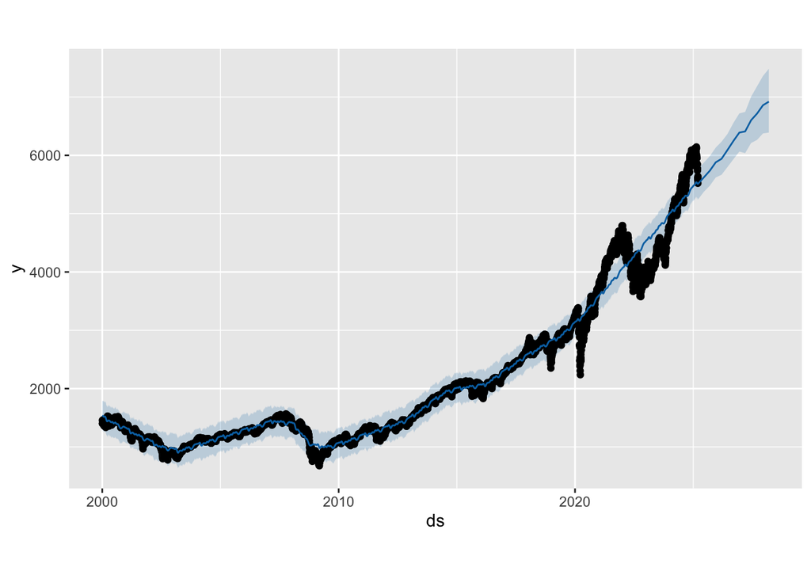

```r
plot(model, pred)
```

## Conclusion

Despite the decline at this moment in time, the model captures past performance well while reducing any noise/volatility, indicating that we will see a recovery of some sort in the coming quarters. At this moment in time however, there is a trade war between the US and the rest of the world. Will the world boycott US companies? We are yet to see what happens…

`---`

Let’s dive deeper into some companies in the S&P. Our fun here wouldn’t be complete without some **Tesla** forecasting. As of recent, the company has received some backlash on Elon Musk’s behaviour. He owns **12%** of the company, so his net worth has most definitely taken some kind of hit. Is it really cause of that, or is it because of the recent weak fundamentals that the company possesses? It’s taken a hit on sales and revenue, with the P/E ratio currently at **low triple figures**. An overvalued company, some might say.

##### Importing Tesla data:

```r
getSymbols("TSLA", src = "yahoo", from = "2010-06-29")
```

## Tesla

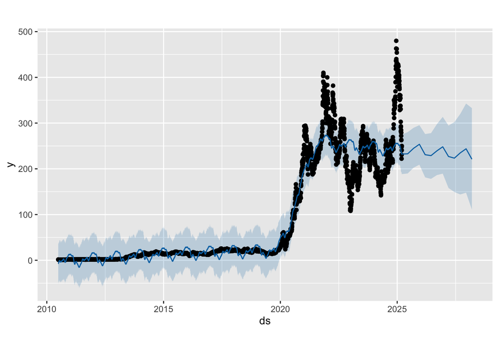

We can observe that there is a greater degree of uncertainty here. It also seems to be a downward trend, with the upper limit of the confidence interval being a little bit more optimistic. It’s not looking good for Mr. Musk. Can he turn it around with the release of his self-driving tech?

`---`

Next… Nvidia. A **big, big game player** in computational power and revolutionary GPU’s. I remember when I tried to get a hold of their flagship 3090Ti a few years ago. I couldn’t get a sniff at it. Out of stock everywhere. So I just decided to buy a really good MacBook and gave up on building my own PC. The stock was genuinely flying, even nearly **tripling** in price in 2024. Only for a certain Deepseek to come through and demonstrate that LLM’s don’t need such rigorous computational footpints to operate well. **$279bn** lost in one day I believe. Ouch. Let’s check out some market performance.

##### Fetching data from Nvidia’s IPO date-present:

```r
getSymbols("NVDA", src = "yahoo", from = "1999-01-22")
```

## NVIDIA

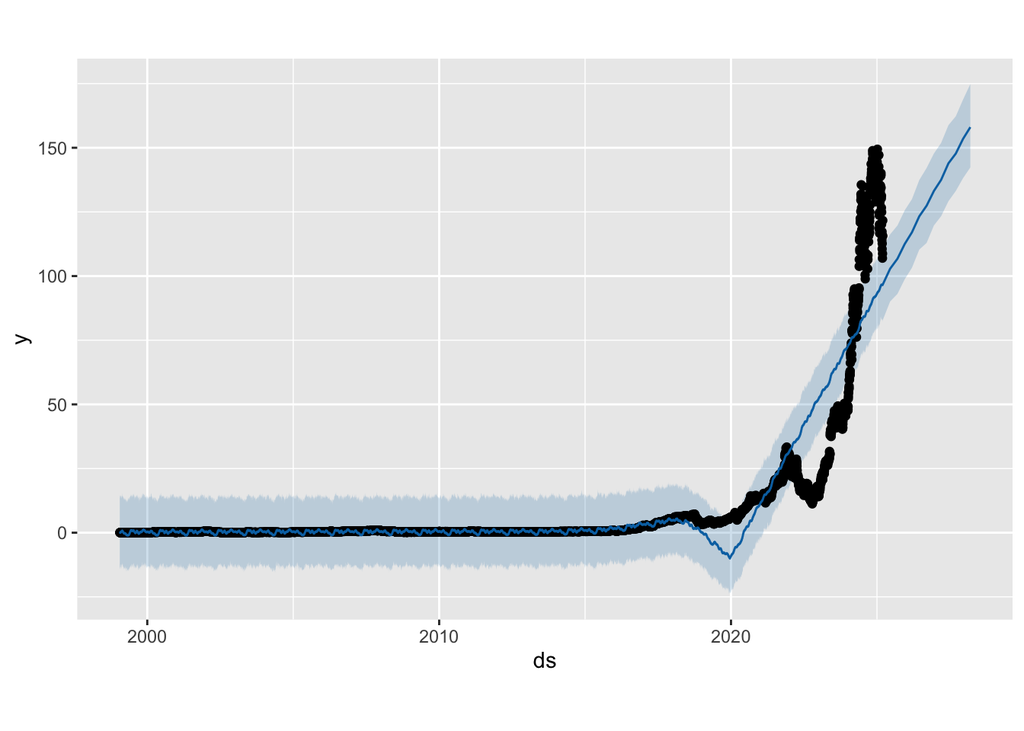

##### What if we take 15+ years worth of data away for prophet to forecast? I’m curious to see what happens.

```r
getSymbols("NVDA", src = "yahoo", from = "2015-01-01")
```

## NVIDIA (2015-present)

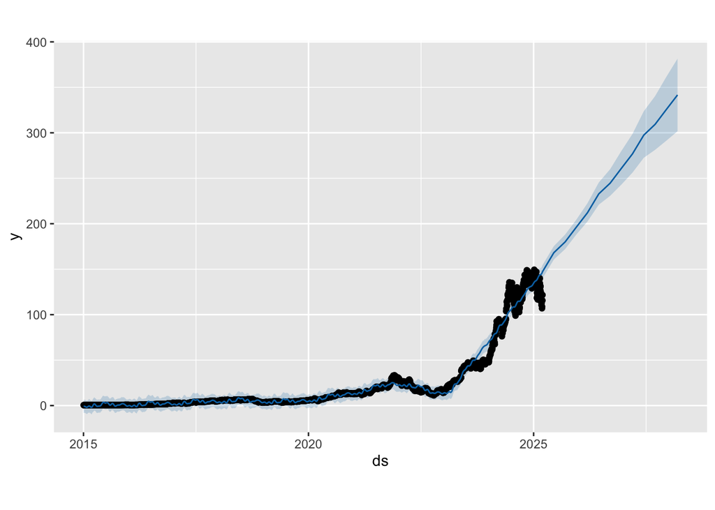

`---`

What about **defense** stocks? Unfortunately, there is a lot of war and conflict in the world. There is a need for defense spending. Recently, the UK increased their defense budget to **2.5% of GDP** after pressure from U.S. President Donald Trump to meet NATO targets and uncertainty of the war in Ukraine. USA spend around **5% of GDP** on defense. A key player in this industry is **Northrop Grumman**; a US defense and security company. They hold multiple contracts with the US government and NASA, and are suppliers of key tech used in space and defense.

```r
getSymbols("NOC", src = "yahoo", from = "2000-01-01")
```

## Northrop Grumman

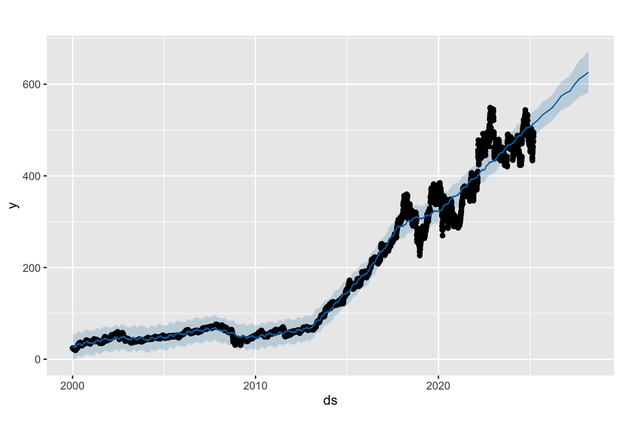

```r
getSymbols("NOC", src = "yahoo", from = "2020-01-01")
```

## Northrop Grumman (2020-present)

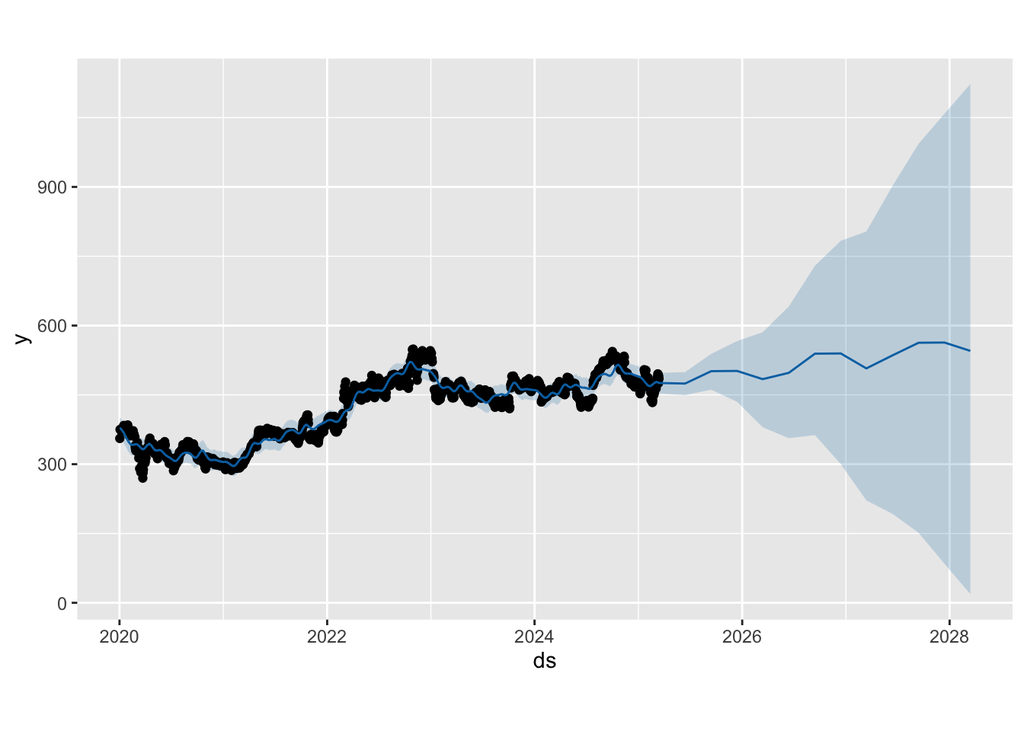

The prophet forecasting model has shown us something quite different here. Unlike the previous model which took into account data since 2000, recent volatility since 2020 has caused a much larger scale of uncertainty. The forecast does suggest there will be slight upward growth. It seems that with the given data, the model provides a more general prediction, suggesting that Northrop Grumman stock can go up or down. I’m not too sure I have an appetite for such risk. Although, due to government contracts and worldwide defense spending increases, will this stock continue to flourish? I think we are more likely to see an upward trend here.

##### However, there’s a small issue here. We have relied too much on projections, which will not always be accurate.

In the finance industry in particular, these projections are not going to be looked at seriously. Especially those who are strong believers in the **efficient market hypothesis**.

Let’s do some other type of analysis.

It is likely that the data is **heteroskedastic**. As in, $\text{Var}(X_t)$ depends on $t$. So variance varies over time.

This is a problem, because we cannot analyse our residual error term, $y_t$, well enough.

We can fix this by doing a transformation of data. One might consider the **Box-Cox transformations**. These are the following family of functions:

$$\text{BoxCox}(x_t) =
\begin{cases} (x_t^\lambda - 1) / \lambda, & \lambda \neq 0 \\
\ln (x_t), & \lambda = 0 \end{cases}$$
where $\lambda$ is our maximum likelihood estimate.

For simplicity, we will take the natural log, $ln$, of Northrop Grumman prices:

```r
log_price <- log(df_5$y)
```

And then we plot:

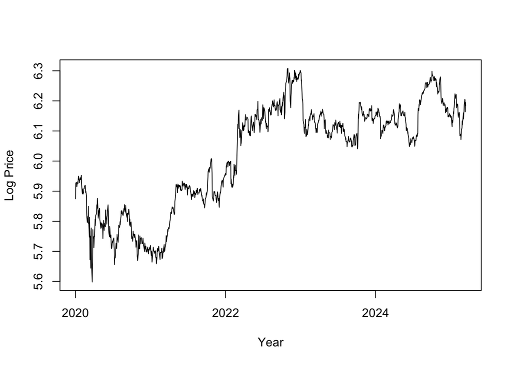

This opens up the door to work on some AR-1 models and analysing random walks with variance ratio, ADF or Ljung-Box tests. This will validate whether our forecasted models are even useful or not.

We won’t focus on those right now, but rather, let’s do some linear regression to determine average annual growth for Northrop Grumman since 01/01/2000.

##### Let’s build our linear regression model. But first, we must extract **just the year** from the data:

```r
df_4$year <- as.numeric(format(df_4$ds, "%Y"))
model <- lm(y ~ year, data = df_4)
```

##### Now let’s look at our beta’s and determine whether the model is a good fit for this data:

```r
summary(model)
```

```
##
## Call:
## lm(formula = y ~ year, data = df_4)
##
## Residuals:
##      Min       1Q   Median       3Q      Max
## -124.492  -63.422    4.324   50.078  188.493
##
## Coefficients:
##               Estimate Std. Error t value Pr(>|t|)
## (Intercept) -3.820e+04  2.297e+02  -166.3   <2e-16 ***
## year         1.907e+01  1.141e-01   167.1   <2e-16 ***
## ---
## Signif. codes:  0 '***' 0.001 '**' 0.01 '*' 0.05 '.' 0.1 ' ' 1
##
## Residual standard error: 66.06 on 6336 degrees of freedom
## Multiple R-squared:  0.815,  Adjusted R-squared:  0.815
## F-statistic: 2.792e+04 on 1 and 6336 DF,  p-value: < 2.2e-16
```

Our $\beta_1$ suggests that Northrop Grumman has grown at an average figure of **$19.07** per year. It also looks like our linear regression model explains a large portion of our variance with $R^2$ **= 81.48%**, so it explains our data well. The model is also statistically significant at a **5%** significance level, so it is a good fit for this data.

##### We can stabilise variance by finding the log return over time. Using too much data won’t work here, so I will fetch prices between 01/01/2020-01/01/2025.

```r
getSymbols("NOC", src = "yahoo", from = "2020-01-01", to = "2025-01-01")
```

##### Here, I am extracting closing prices and taking the logarithms:

```r
log_returns <- diff(log(Cl(NOC)))
```

##### Let’s double check that everything is running smoothly:

```r
head(log_returns)
```

```
##               NOC.Close
## 2020-01-02           NA
## 2020-01-03  0.052865005
## 2020-01-06  0.002184159
## 2020-01-07 -0.002290852
## 2020-01-08 -0.012559521
## 2020-01-09  0.005574583
```

##### And now we plot our time series:

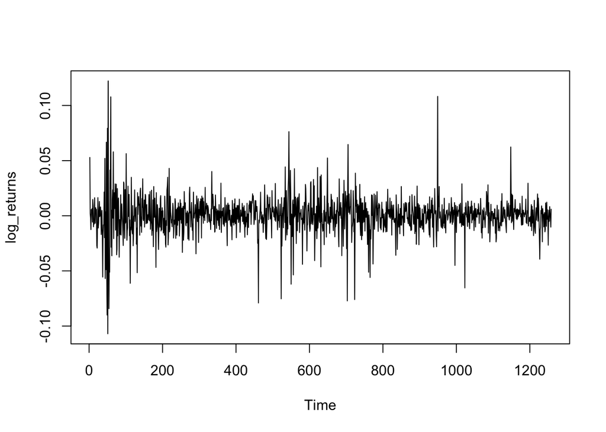

```r
plot.ts(log_returns)
```

This time series showcases daily empirical returns. This is excellent if you want to compare it to other models such as the **AR-1 model**, or the market fit of a **lognormal model**. There are **some extreme returns at over 10%**, and **one extreme loss just over 10%**.

For fun, we can check whether returns of Northrop Grumman are lognormally distributed:

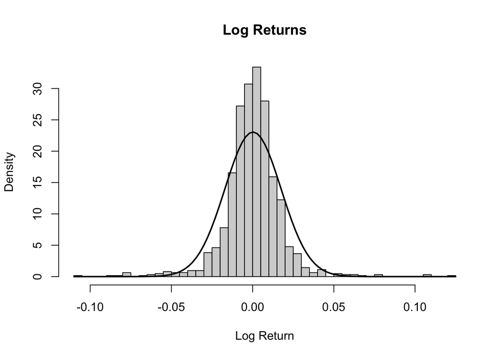

```r
hist(log_returns, breaks = 50, prob = TRUE, main = "Log Returns", xlab = "Log Return")
curve(dnorm(x, mean(log_returns, na.rm = TRUE), sd(log_returns, na.rm = TRUE)), lwd = 2, add = TRUE)
```

This is a property that we can check further by performing normality tests and Q-Q Plots, but we won’t do that now.

Let’s now focus on decomposing our data. A stock like Northrop Grumman can perform better or worse at certain times of the year. We can explore the components of the **additive model**.

##### Recalling our additive model:

$$X_t = m_t + S_t + Y_t, \quad t = 1, \dots, n.$$

Let’s decompose our time series and get a visual feel for each element. We can do this by using the decompose() function. I am also assuming that there are **252** trading days per year.

##### First, we decompose our time series:

```r
ts_data <- ts(df_4$y, start = c(2000, 1), frequency = 252)
components_ts <- decompose(ts_data)
```

##### Our trend, seasonal and residual error components are now stored in components_ts. We can access some values of the seasonal component, for e.g.

```r
head(components_ts$seasonal)
```

```
## [1] -1.141216 -1.586996 -1.733153 -1.238553 -1.916531 -2.165309
```

##### Then we plot our elements:

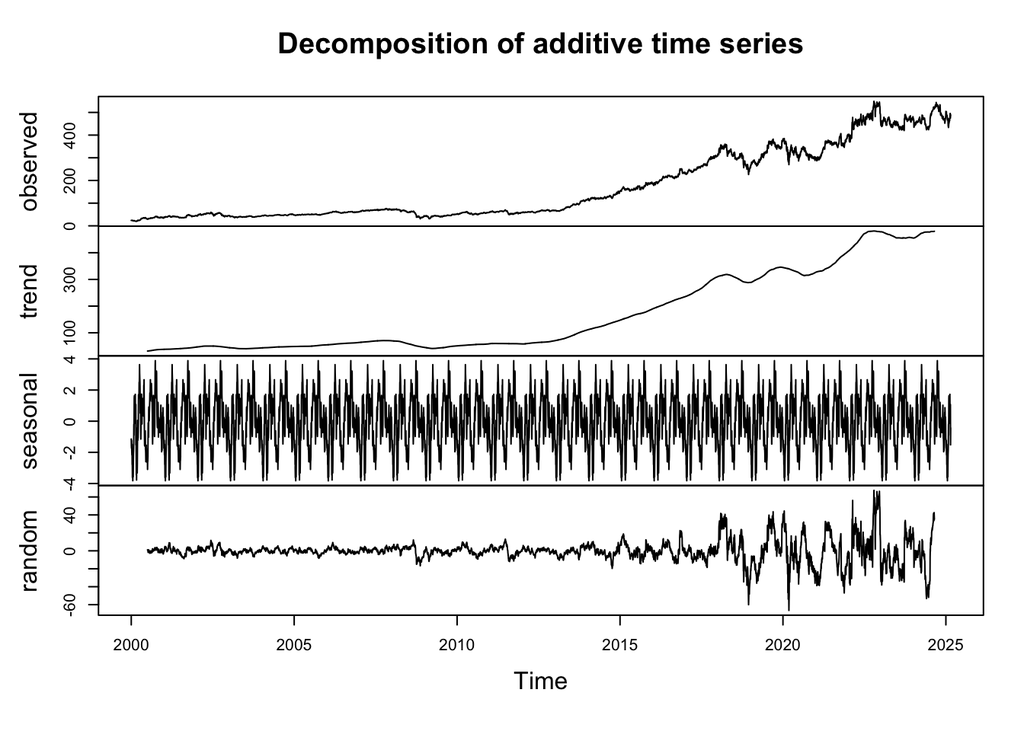

```r
plot(components_ts)
```

Our trend component $m_t$ showcases constant growth from 2014 to 2018. Overall, the trend is still at an upward trajectory. The seasonal component $S_t$ shows a pattern which indicates that there is a possible month or two during a trading year where Northrop Grumman saw the most growth, on average. This is usually weakly defined when it comes to the stock market. The random component becomes more responsive after 2018, indicating periods of highs and lows for Northrop Grumman. In fact, in 2018, the company was under some fire for overbilling the US Air Force, leading to settlements in court worth millions of dollars.

##### Taking a closer look at our seasonality component:

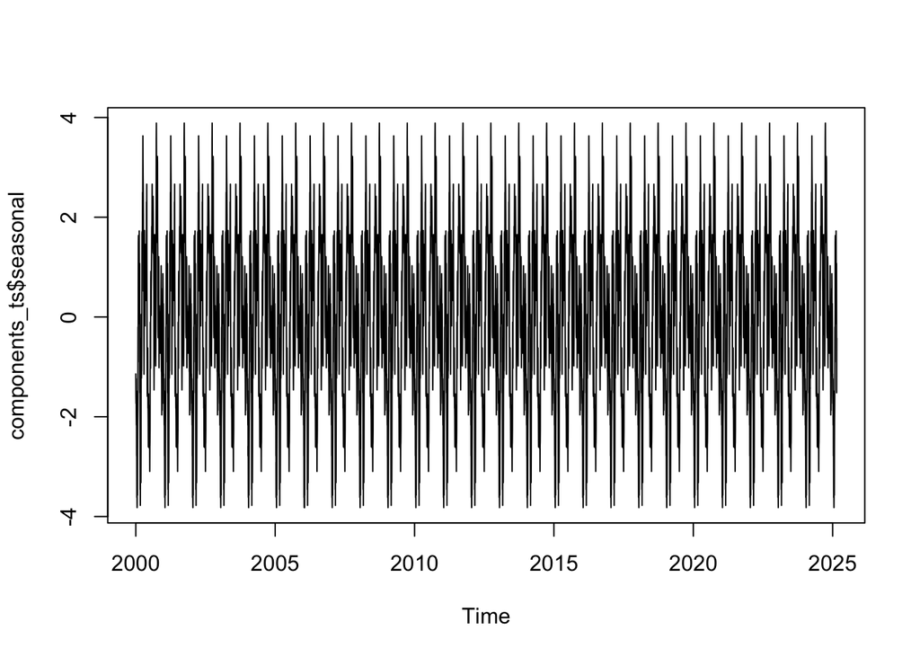

```r
plot(components_ts$seasonal)
```

##### Given that we are working with the additive model, we can do some **seasonal adjusting** by taking away the seasonal component from our time series.

##### But does the seasonal component here really even make an impact?

```r
adjusted_ts <- ts_data - components_ts$seasonal
```

##### Now we plot both the adjusted time series data (without a seasonal component) and the original time series for comparison:

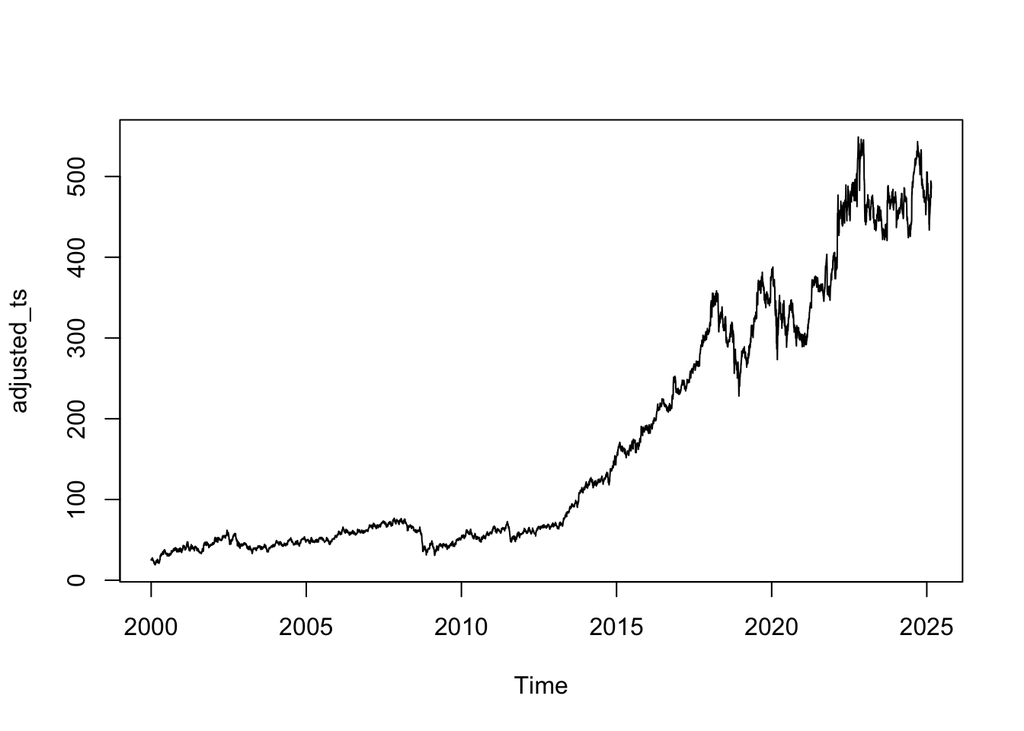

```r
plot(adjusted_ts)
```

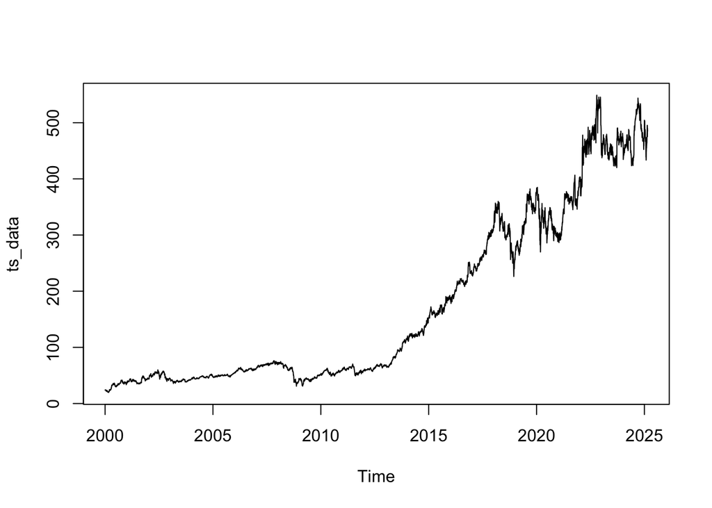

```r
plot(ts_data)
```

How interesting…

There is not much difference here, but observe year **2000-2010**. The time series does look a little smoother. However, it seems that the seasonal component is **not** really useful in the additive model and doesn’t contribute much.

This shows that there is **weak** evidence to suggest any cyclical trend patterns when it comes to growth or loss for Northrop Grumman.

It also upholds the weak form of the efficient market hypothesis (at the very least, given there are stronger forms which frown upon fundamental analysis too); technical analysis doesn’t seem too useful.

Hope you enjoyed reading!